# Assignment 3 example answer key

Phil Hurvitz | e-mail | [www](http://gis.washington.edu/phurvitz)

2021-02-01 20:30

```r
# key setups
library(sqldf) # to use sql syntax with data frames
library(knitr) # knitr for kable tables
library(kableExtra) # pretty tables
library(sf) # simple features (GIS)
library(leaflet) # nice maps
library(tools) # md5sum
library(ggplot2)
library(tidyverse)

# captions
library(captioner)
table_nums <- captioner(prefix = "Table")
figure_nums <- captioner(prefix = "Figure")

# for having DIV tags
knitr::knit_hooks$set(class = function(before, options, envir) {
  if(before){
    sprintf("<div class = '%s'>", options$class)
  }else{
    "</div>"
  }
})

knitr::opts_chunk$set(warning = FALSE, message = FALSE)
```

# Introduction

This document serves the purpose of demonstrating that I have learned to use R Markdown for communicating scientific information. The assignment's instructions included the following requirements:

1. Your name and contact information
2. Date of creation
3. A table of contents
4. Sequentially numbered section headers
5. At least one figure with a caption
6. At least one table with a caption
7. At least one LaTeX-generated equation with an equation number
8. Code-generated cross-references within the text to the figure, table, and equation (use any of the cross-referencing methods presented in the lesson)
9. At least one citation and a bibliography (note: BibTeX formatted reference data can be exported from EndNote, Mendeley, and Zotero)
10. Source code at the end of the document as shown in previous examples

The scientific content is a brief analysis of the [unrestricted Add Health data](http://staff.washington.edu/phurvitz/csde502_winter_2021/data/AHwave1_v1.dta).

The numbered sections correspond to the assignment requirements, as described in each section.

# 1 Name and contact information

See above, my name as well as hyperlinks to my e-mail address and web page. These were included in the YAML header as

```
author: "Phil Hurvitz | [e-mail](mailto:phurvitz@uw.edu) | [www](http://gis.washington.edu/phurvitz)"
```

# 2 Date of creation

The time stamp of creation is automatically included as part of the YAML header:

```
date: '2021-02-01 20:30'
```

# 3 A table of contents

The table of contents is presented at the upper left of the HTML document using the directive `toc: true` and with options for floating, collapsing, and smooth scrolling in the YAML header code:

```
output:
    bookdown::html_document2:
    ...
        toc: true
        toc_float:
            collapsed: true
            smooth_scroll: false
```

# 4 Sequentially numbered section headers

Section numbers are added by including the YAML header directive `number_sections: true`.

```
output:
    bookdown::html_document2:
        number_sections: true
```

# 5 At least one figure with a caption

```r
# read the data set
dat <- readstata13::read.dta13("http://staff.washington.edu/phurvitz/csde502_winter_2021/data/AHwave1_v1.dta")

# pull some race and depression data
# include a conversion to integer, where 1 = false, 2 = true, else NA
d <- dat %>%
    select(felt_depressed = h1fs6,
           White = h1gi6a,
           AfrAm = h1gi6b,
           Asian = h1gi6d,
           Hispanic = h1gi4
           ) %>%
    mutate_all(as.integer) %>%
    mutate_all(funs(case_when(
                    . == 1 ~ FALSE,
                    . == 2 ~ TRUE,
                    TRUE ~ NA)))


# melt and tabulate
dsum <- d %>%
    gather(race, race_bool, -felt_depressed) %>%
    filter(race_bool) %>%
    group_by(race, race_bool, felt_depressed) %>%
    summarise(n = n(),
              .groups = "rowwise") %>%
    group_by(race) %>%
    mutate("pct" = n / sum(n) * 100,
           label = pct %>% round(1)) %>%
    ungroup()

# some numbers
white_depressed <- dsum %>% filter(race == "White" & felt_depressed) %>% select(label)
asian_depressed <- dsum %>% filter(race == "Asian" & felt_depressed) %>% select(label)

# chi-square test
chisq_pvalue <- dsum %>% filter(felt_depressed) %>%
    select (race, pct) %>%
    summarize(pval = chisq.test(pct)$p.value) %>%
    pull() %>% round(2) %>% str_replace("^0", "")
```

The analysis for this document was a comparison of the proportion of respondents who reported feelings of depression stratified by race/ethnicity. The variable `h1fs6` represented whether respondents felt depressed, and the variables `h1gi6a`, `h1gi6b` , `h1gi6d` , `h1gi4` represented White, African American, Asian, and Hispanic race/ethnicity.

A few important notes about the data:

- Race/ethnicity categories were not mutually exclusive, therefore, a single respondent could have self-identified in up to all four race/ethnicity categories.
- Responses that were either refused or "don't know" were classified as "missing" (i.e., `NA`).

As shown in Figure 1, there were minor differences in the proportion of respondents who felt depressed, with Whites having the lowest (27.9%), and Asians having the highest (34.4%) rates of depression.

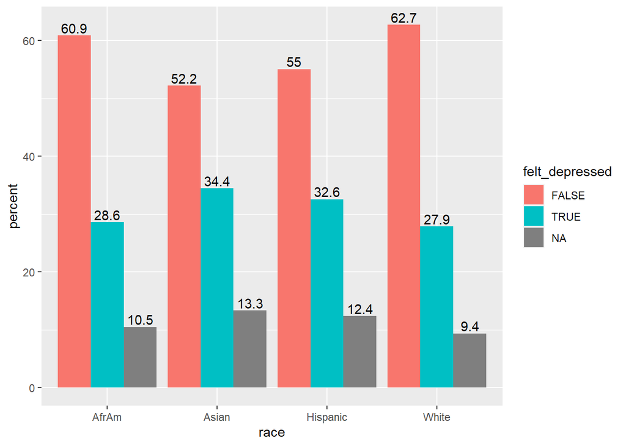

```r
# boxplot
g <- ggplot(data = dsum, mapping = aes(x = race, y = `pct`, fill = felt_depressed)) +
    geom_col(position = 'dodge') +
    geom_text(aes(label=label), position=position_dodge(width=0.9), vjust=-0.25) +
    ylab("percent")
g
```

*Figure 1: Percent of respondents who felt depressed, stratified by race/ethnicity*

# 6 At least one table with a caption

In addition to the proportions shown in Figure 1, the raw counts and proportions are shown in Table 1.

*Table 1: Counts and proportions of feeling depressed, by race/ethnicity*

```r
dsum_print <- dsum %>%
    filter(!is.na(felt_depressed)) %>%
    mutate(percent = round(pct, 1)) %>%
    select (race, "felt depressed" = felt_depressed, n, percent)

kable(dsum_print, format = "html") %>%
  kable_styling(bootstrap_options =
                  c("striped", "hover", "condensed", "responsive"),
                full_width = F,
                position = "left")
```

| race | felt depressed | n | percent |
| --- | --- | --- | --- |
| AfrAm | FALSE | 986 | 60.9 |
| AfrAm | TRUE | 463 | 28.6 |
| Asian | FALSE | 141 | 52.2 |
| Asian | TRUE | 93 | 34.4 |
| Hispanic | FALSE | 409 | 55.0 |
| Hispanic | TRUE | 242 | 32.6 |
| White | FALSE | 2694 | 62.7 |
| White | TRUE | 1197 | 27.9 |

# 7 At least one $\LaTeX$-generated equation with an equation number

To determine whether these proportions were significantly different across race/ethnicities, a $\chi^{2}$ test `(7.1)` was run.

$$\begin{equation}
{\chi}^2=\frac{1}{d}\sum_{k=1}^{n} \frac{(O_k - E_k)^2}{E_k}
\tag{7.1}
\end{equation}$$

The P value of the test was .81. Note: see [Statistical Rounding and the (Mis)Leading Zero](https://amastyleinsider.com/2011/08/17/statistical-rounding-and-the-misleading-zero/) for why there is no leading zero to the left of the decimal place of the P value.

# 8 Code-generated cross-references within the text to the figure, table, and equation (use any of the cross-referencing methods presented in the lesson)

All of the table, figure, and equation captions and cross references are driven by R code. See the source code for details.

# 9 At least one citation and a bibliography (note: BibTeX formatted reference data can be exported from EndNote, Mendeley, and Zotero)

The rudimentary analysis presented here pales in comparison to a more nuanced treatment (Hargrove et al. 2020), which used the complete Add Health data, several questions about depressive symptoms, stratified the race/ethnicities by gender, and controlled for age, being born in the US, and the count of waves in which respondents were interviewed (to account for missing waves of data).

The single reference was placed in assignment03.bib and specified in the YAML header as

[output not shown]

# References cited

Hargrove, Taylor W., Carolyn T. Halpern, Lauren Gaydosh, Jon M. Hussey, Eric A. Whitsel, Nancy Dole, Robert A. Hummer, and Kathleen Mullan Harris. 2020. “Race/Ethnicity, Gender, and Trajectories of Depressive Symptoms Across Early- and Mid-Life Among the Add Health Cohort.” *J. Racial Ethn. Heal. Disparities* 7 (4). Journal of Racial; Ethnic Health Disparities: 619–29. doi:10.1007/s40615-019-00692-8.

# 10 Source code at the end of the document as shown in previous examples

```r
cat(readLines("csde502_2021_assignment03_answers.Rmd"), sep = '\n')
```

````
---
title: "Assignment 3 example answer key"
author: "Phil Hurvitz | [e-mail](mailto:phurvitz@uw.edu) | [www](http://gis.washington.edu/phurvitz)"
date: '`r format(Sys.time(), "%Y-%m-%d %H:%M")`'
header-includes: #allows you to add in your own Latex packages
- \usepackage{float} #use the 'float' package
- \floatplacement{figure}{H} #make every figure with caption = h
output:
    bookdown::html_document2:
        number_sections: true
        self_contained: true
        code_folding: hide
        toc: true
        toc_float:
            collapsed: true
            smooth_scroll: false
urlcolor: blue
bibliography: assignment03.bib
---

<!--these following settings control width and also make a DIV tag for black outlines for figures-->
<style type="text/css">
.main-container {
  max-width: 2400px !important;
  margin-left: auto;
  margin-right: auto;
}
</style>

<style>
.outline {
   background-color: #000000;
   padding:1px;
   display: inline-block;
}
</style>

```{r setup, message=FALSE, warning=FALSE}
# key setups
library(sqldf) # to use sql syntax with data frames
````

[output cut: 196 more lines]

[output not shown]